# Statistical Methods for Insurance: Linear Models

W4.C2

## Overview of this class

- Fitting a linear model to olympic medal tally
- Review of linear regression
- READING: Ch 5, Diez, Barr, Cetinkaya-Rundel

## Modeling Olympic medal counts

| term | estimate | std.error | statistic | p.value |
| --- | --- | --- | --- | --- |
| (Intercept) | 1.28 | 0.67 | 1.91 | 0.06 |
| Total.2008 | 0.91 | 0.04 | 20.80 | 0.00 |
| Pop_std | -0.51 | 0.54 | -0.94 | 0.35 |
| GDP_std | 1.27 | 0.85 | 1.50 | 0.14 |

\[M_{2012} = \beta_0 + \beta_1 M_{2008} + \beta_2 Population + \beta_3 GDP + \varepsilon\]

## Model summary

```
#>   null.deviance df.null logLik AIC BIC deviance df.residual
#> 1         30252      84   -242 494 507     1486          81
```

## Fit and residuals

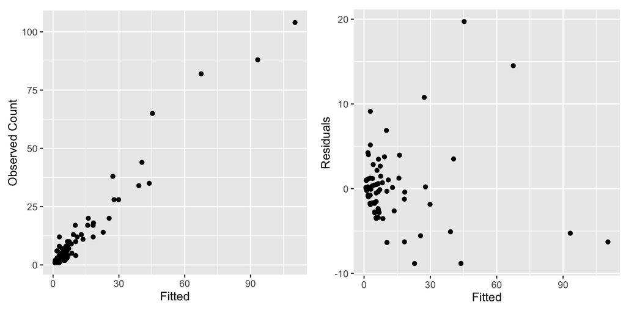

## Make plots interactive

[interactive chart not shown]

## Make plots interactive

[interactive chart not shown]

## Simple linear model

\[Y = \beta_0 + \beta_1 X + \varepsilon\]

- Explains how response variable (\(Y\)) changes in relation to explanatory variable (\(X\)), on average.
- Use line to predict value of \(Y\) for a given value of \(X\)

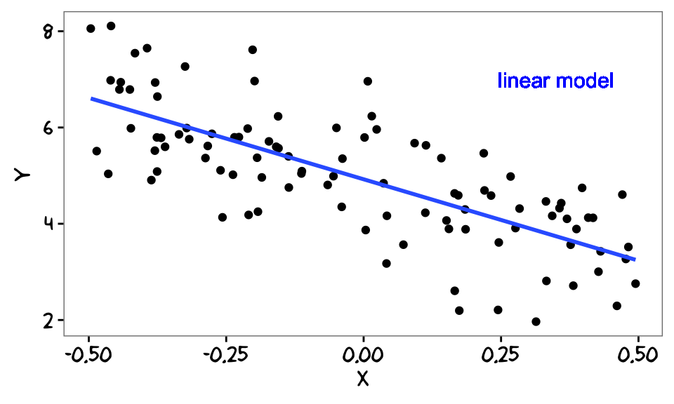

## Observed, fitted, residuals

- Observed value is \(Y\) (a point on plot)
- Fitted value is \(\hat{Y}\), a value that lies on the line
- Residual is the difference between observed and fitted, \(e=Y-\hat{Y}\)

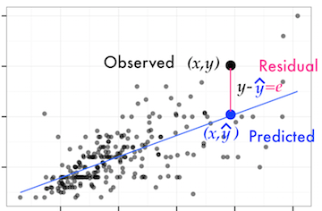

## Fitting process

- Minimizing the sum of squared residuals produces the best fitting line.
- Minimizes \(\sum e^2\)
- Line that is closest to the points, as a whole.

## Parameter interpretation

- Line of best fit: \(\hat{Y}=b_0+b_1X\)
- \(b_0\) is the intercept of the line with y-axis
- \(b_1\) is the slope of the line

## Calculating manually

Given standard deviation of \(X\), \(s_x\), standard deviation of \(Y\), \(s_y\), and the correlation, \(r\), between the two, the slope is computed by

\[b_1 = r\frac{s_y}{s_x}\]

and given the sample means \(\bar{X}, \bar{Y}\)

\[b_0 = \bar{Y} - b_1\bar{X}\]

## YOUR TURN

Is the point \(\bar{X}, \bar{Y}\) on the regression line?

## Prediction

For given \(X\) values, plug these into the model equation to predict \(Y\),

\[\hat{Y} = b_0 + b_1 X\]

## Goodness of fit

- \(R^2\) is the proportion of variation in \(Y\) that is explained by \(X\). Computed by  
  \[ R^2 = 1- \frac{\sum e^2}{\sum Y^2} \]
- Deviance: up to a constant, minus twice the maximized log-likelihood

## Reading residual plots

- Make a histogram and normal probability plot of the residuals - for a good fit the shape should be pretty symmetric and bell-shaped
- Plot the residuals against the fitted values - for a good fit should be just a random splatter, no patterns

## Residual plots

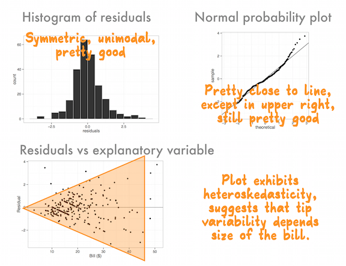

## Diagnostics

- Influential points: leverage (diagonal elements of hat matrix, values \(> 2p/n\) would indicate cases with high influence), cooksd (Cooks distance, measures the change in the residual when the case is removed)
- Collinearity between explanatory variables (multiple regression): variance inflation factor

## Cautions

- Association is not causation
- Linear association only
- Extrapolation outside the range of the data is not recommended

## Anscombe's quartet

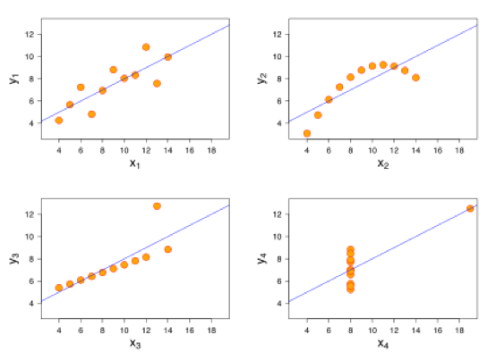

Always plot the data, because very different patterns can lead to the same correlation.

## Resources

- [Statistics online textbook, Diez, Barr, Cetinkaya-Rundel](https://www.openintro.org/stat/textbook.php?stat_book=isrs)
- [Ancombe's quartet](http://en.wikipedia.org/wiki/Anscombe's_quartet)

## Share and share alike

This work is licensed under the Creative Commons Attribution-Noncommercial 3.0 United States License. To view a copy of this license, visit http://creativecommons.org/licenses/by-nc/ 3.0/us/ or send a letter to Creative Commons, 171 Second Street, Suite 300, San Francisco, California, 94105, USA.